# **Linking Partisanship and Social Media Engagement**

Created by Emma Jones and Maggie Parsons

*Website Link:* https://teragram04.github.io/

# Project Plans and Dataset

**Project Plan**

With the advent of social media, humanity has never been more connected. However, with this connection comes the ability to see opinions on politics from people one has never met, in addition to providing politicians with large platforms. Using the data from Kaggle, We will analyze the link between partisanship, party identity and social media engagement, especially focusing on the proportion of partisan versus neutral messaging, and what these messages advocate for (policy changes, providing information, etc.) We will continue to look for additional datasets to augment our current data.

**Collaboration Plan**

The students behind this paper intend to collaborate through arranging times to work through Slack. We will meet to discuss the milestone criteria, then divide the work evenly. Additionally, we will check in with each other to ensure that we stay on track for project completion.

**The Dataset**

The dataset we will be examining is "[Political Social Media Posts](https://www.kaggle.com/datasets/crowdflower/political-social-media-posts)", pulled from Kaggle. This dataset provides a sample of 5,000 social media posts from various politicians, and categorizes them based on a myriad of variables such as bias, intended audience, a unique id for the politician, and more. This dataset will allow us to determine which kind of message politicians use the most to garner support online- e.g., do politicans favor a national audience, or one primarily composed of their constituency?

# Loading the Data

Before examining the data, let us import the necessary libraries and clone our github website to this notebook (this is where we decided to store our dataset).

```python
import pandas as pd
import numpy as np
import matplotlib.pyplot as plt
!git clone https://github.com/Teragram04/Teragram04.github.io
%cd Teragram04.github.io
```

[output not shown]

Now, we'll load in the dataset. Let's examine it before making any changes.

```python
# Original Dataset
kgposts = pd.read_csv('political_social_media.csv', encoding='iso-8859-1')
kgposts.head()
```

|  | _unit_id | _golden | _unit_state | _trusted_judgments | _last_judgment_at | audience | audience:confidence | bias | bias:confidence | message | ... | orig__golden | audience_gold | bias_gold | bioid | embed | id | label | message_gold | source | text |
| --- | --- | --- | --- | --- | --- | --- | --- | --- | --- | --- | --- | --- | --- | --- | --- | --- | --- | --- | --- | --- | --- |
| 0 | 766192484 | False | finalized | 1 | 8/4/15 21:17 | national | 1.0 | partisan | 1.0 | policy | ... | NaN | NaN | NaN | R000596 | <blockquote class="twitter-tweet" width="450">... | 3.83249E+17 | From: Trey Radel (Representative from Florida) | NaN | twitter | RT @nowthisnews: Rep. Trey Radel (R- #FL) slam... |
| 1 | 766192485 | False | finalized | 1 | 8/4/15 21:20 | national | 1.0 | partisan | 1.0 | attack | ... | NaN | NaN | NaN | M000355 | <blockquote class="twitter-tweet" width="450">... | 3.11208E+17 | From: Mitch McConnell (Senator from Kentucky) | NaN | twitter | VIDEO - #Obamacare: Full of Higher Costs and ... |
| 2 | 766192486 | False | finalized | 1 | 8/4/15 21:14 | national | 1.0 | neutral | 1.0 | support | ... | NaN | NaN | NaN | S001180 | <blockquote class="twitter-tweet" width="450">... | 3.39069E+17 | From: Kurt Schrader (Representative from Oregon) | NaN | twitter | Please join me today in remembering our fallen... |
| 3 | 766192487 | False | finalized | 1 | 8/4/15 21:08 | national | 1.0 | neutral | 1.0 | policy | ... | NaN | NaN | NaN | C000880 | <blockquote class="twitter-tweet" width="450">... | 2.98528E+17 | From: Michael Crapo (Senator from Idaho) | NaN | twitter | RT @SenatorLeahy: 1st step toward Senate debat... |
| 4 | 766192488 | False | finalized | 1 | 8/4/15 21:26 | national | 1.0 | partisan | 1.0 | policy | ... | NaN | NaN | NaN | U000038 | <blockquote class="twitter-tweet" width="450">... | 4.07643E+17 | From: Mark Udall (Senator from Colorado) | NaN | twitter | .@amazon delivery #drones show need to update ... |

5 rows × 21 columns

It looks like the chart loaded in correctly! However, there are columns here that we do not need. According to Kaggle's summary of the data, some of these variables were only utilized during the initial data collection, and provide no additional information. Let's clean up this table by removing the unnecessary columns.

```python
#The following columns were used in data collection, and will not be
#relevant for analysis. this will delete uneccesary columns
kgposts = kgposts.drop(['message_gold','orig__golden','audience_gold',
                        'bias_gold','_unit_state', '_golden'], axis=1)


kgposts.head()
```

|  | _unit_id | _trusted_judgments | _last_judgment_at | audience | audience:confidence | bias | bias:confidence | message | message:confidence | bioid | embed | id | label | source | text |
| --- | --- | --- | --- | --- | --- | --- | --- | --- | --- | --- | --- | --- | --- | --- | --- |
| 0 | 766192484 | 1 | 8/4/15 21:17 | national | 1.0 | partisan | 1.0 | policy | 1.0 | R000596 | <blockquote class="twitter-tweet" width="450">... | 3.83249E+17 | From: Trey Radel (Representative from Florida) | twitter | RT @nowthisnews: Rep. Trey Radel (R- #FL) slam... |
| 1 | 766192485 | 1 | 8/4/15 21:20 | national | 1.0 | partisan | 1.0 | attack | 1.0 | M000355 | <blockquote class="twitter-tweet" width="450">... | 3.11208E+17 | From: Mitch McConnell (Senator from Kentucky) | twitter | VIDEO - #Obamacare: Full of Higher Costs and ... |
| 2 | 766192486 | 1 | 8/4/15 21:14 | national | 1.0 | neutral | 1.0 | support | 1.0 | S001180 | <blockquote class="twitter-tweet" width="450">... | 3.39069E+17 | From: Kurt Schrader (Representative from Oregon) | twitter | Please join me today in remembering our fallen... |
| 3 | 766192487 | 1 | 8/4/15 21:08 | national | 1.0 | neutral | 1.0 | policy | 1.0 | C000880 | <blockquote class="twitter-tweet" width="450">... | 2.98528E+17 | From: Michael Crapo (Senator from Idaho) | twitter | RT @SenatorLeahy: 1st step toward Senate debat... |
| 4 | 766192488 | 1 | 8/4/15 21:26 | national | 1.0 | partisan | 1.0 | policy | 1.0 | U000038 | <blockquote class="twitter-tweet" width="450">... | 4.07643E+17 | From: Mark Udall (Senator from Colorado) | twitter | .@amazon delivery #drones show need to update ... |

Now that we have removed unnecessary columns, let us check to make sure all the remaining columns are the correct dtype.

We'd further like to analyze certain characteristics by party membership and state. So we'll need to isolate these characteristics from the label column.

```python
kgposts['legislator_Name'] = kgposts['label'].str.extract(r'From: (.*?) \(')
kgposts['state'] =kgposts['label'].str.extract(r'from ([A-Za-z\s]+)\)')
kgposts.head()
```

|  | _unit_id | _trusted_judgments | _last_judgment_at | audience | audience:confidence | bias | bias:confidence | message | message:confidence | bioid | embed | id | label | source | text | legislator_Name | state |
| --- | --- | --- | --- | --- | --- | --- | --- | --- | --- | --- | --- | --- | --- | --- | --- | --- | --- |
| 0 | 766192484 | 1 | 8/4/15 21:17 | national | 1.0 | partisan | 1.0 | policy | 1.0 | R000596 | <blockquote class="twitter-tweet" width="450">... | 3.83249E+17 | From: Trey Radel (Representative from Florida) | twitter | RT @nowthisnews: Rep. Trey Radel (R- #FL) slam... | Trey Radel | Florida |
| 1 | 766192485 | 1 | 8/4/15 21:20 | national | 1.0 | partisan | 1.0 | attack | 1.0 | M000355 | <blockquote class="twitter-tweet" width="450">... | 3.11208E+17 | From: Mitch McConnell (Senator from Kentucky) | twitter | VIDEO - #Obamacare: Full of Higher Costs and ... | Mitch McConnell | Kentucky |
| 2 | 766192486 | 1 | 8/4/15 21:14 | national | 1.0 | neutral | 1.0 | support | 1.0 | S001180 | <blockquote class="twitter-tweet" width="450">... | 3.39069E+17 | From: Kurt Schrader (Representative from Oregon) | twitter | Please join me today in remembering our fallen... | Kurt Schrader | Oregon |
| 3 | 766192487 | 1 | 8/4/15 21:08 | national | 1.0 | neutral | 1.0 | policy | 1.0 | C000880 | <blockquote class="twitter-tweet" width="450">... | 2.98528E+17 | From: Michael Crapo (Senator from Idaho) | twitter | RT @SenatorLeahy: 1st step toward Senate debat... | Michael Crapo | Idaho |
| 4 | 766192488 | 1 | 8/4/15 21:26 | national | 1.0 | partisan | 1.0 | policy | 1.0 | U000038 | <blockquote class="twitter-tweet" width="450">... | 4.07643E+17 | From: Mark Udall (Senator from Colorado) | twitter | .@amazon delivery #drones show need to update ... | Mark Udall | Colorado |

Now, we'll add in a dataset which matches senator names with party. This dataset was compiled by https://unitedstates.github.io/congress-legislators/ using Goverment websites.

```python
# adds current legislators
partydf = pd.read_csv('legislators-current.csv')
selected_columns = ['full_name', 'party']
partydf = partydf[selected_columns]
partydf = partydf.rename(columns={'full_name': 'legislator_Name'})
kgposts = pd.merge(kgposts, partydf, on='legislator_Name', how='left')
```

```python
# adds historical legislators
partydf = pd.read_csv('legislators-historical.csv')
selected_columns = ['full_name', 'party']
partydf = partydf[selected_columns]
partydf = partydf.rename(columns={'full_name': 'legislator_Name', 'party': 'party_hist'}) # Rename 'party' to 'party_hist'
kgposts = pd.merge(kgposts, partydf, on='legislator_Name', how='left')

# Update the 'party' column in kgposts with values from 'party_hist'
kgposts['party'] = kgposts['party'].fillna(kgposts['party_hist'])

# Drop the 'party_hist' column
kgposts = kgposts.drop(columns=['party_hist'])
kgposts.head()
```

|  | _unit_id | _trusted_judgments | _last_judgment_at | audience | audience:confidence | bias | bias:confidence | message | message:confidence | bioid | embed | id | label | source | text | legislator_Name | state | party |
| --- | --- | --- | --- | --- | --- | --- | --- | --- | --- | --- | --- | --- | --- | --- | --- | --- | --- | --- |
| 0 | 766192484 | 1 | 8/4/15 21:17 | national | 1.0 | partisan | 1.0 | policy | 1.0 | R000596 | <blockquote class="twitter-tweet" width="450">... | 3.83249E+17 | From: Trey Radel (Representative from Florida) | twitter | RT @nowthisnews: Rep. Trey Radel (R- #FL) slam... | Trey Radel | Florida | Republican |
| 1 | 766192485 | 1 | 8/4/15 21:20 | national | 1.0 | partisan | 1.0 | attack | 1.0 | M000355 | <blockquote class="twitter-tweet" width="450">... | 3.11208E+17 | From: Mitch McConnell (Senator from Kentucky) | twitter | VIDEO - #Obamacare: Full of Higher Costs and ... | Mitch McConnell | Kentucky | Republican |
| 2 | 766192486 | 1 | 8/4/15 21:14 | national | 1.0 | neutral | 1.0 | support | 1.0 | S001180 | <blockquote class="twitter-tweet" width="450">... | 3.39069E+17 | From: Kurt Schrader (Representative from Oregon) | twitter | Please join me today in remembering our fallen... | Kurt Schrader | Oregon | Democrat |
| 3 | 766192487 | 1 | 8/4/15 21:08 | national | 1.0 | neutral | 1.0 | policy | 1.0 | C000880 | <blockquote class="twitter-tweet" width="450">... | 2.98528E+17 | From: Michael Crapo (Senator from Idaho) | twitter | RT @SenatorLeahy: 1st step toward Senate debat... | Michael Crapo | Idaho | NaN |
| 4 | 766192488 | 1 | 8/4/15 21:26 | national | 1.0 | partisan | 1.0 | policy | 1.0 | U000038 | <blockquote class="twitter-tweet" width="450">... | 4.07643E+17 | From: Mark Udall (Senator from Colorado) | twitter | .@amazon delivery #drones show need to update ... | Mark Udall | Colorado | Democrat |

Some legislators' parties are still missing from the data set

```python
#get a list of all senators whose party is listed as Nan
missing_parties = kgposts[kgposts['party'].isna()]['legislator_Name'].unique()
missing_parties
```

```
array(['Michael Crapo', 'Frederica Wilson', 'Chuck Fleischmann',
       'Steny Hoyer', 'Thomas Carper', 'John Dingell',
       'Kirsten Gillibrand', 'Cory Booker', 'Elizabeth Esty',
       'Orrin Hatch', 'Kerry Bentivolio', 'John Rockefeller IV',
       'Bob Casey', 'Sander Levin', 'C.A. Dutch Ruppersberger',
       'Timothy Bishop', 'Edward Markey', 'Scott Peters', 'Adam Schiff',
       'Robert Scott', 'Robert Goodlatte', 'Yvette Clarke',
       'Michael McCaul', 'Nita Lowey', 'Tom Rooney', 'Tim Walz',
       'Patrick Leahy', 'Jim Langevin', 'Barbara Mikulski', 'Jim Himes',
       'John Boehner', 'Joe Heck', 'Phil Roe', 'Peter Roskam',
       'Bill Enyart', 'Eleanor Norton', 'John Culberson', 'Donna Edwards',
       'Donald Payne Jr.', 'Pat Meehan', 'Michael Fitzpatrick',
       'Sheila Jackson-Lee', 'AndrÌ© Carson', 'Robert Wittman',
       'Sean Maloney', 'Benjamin Cardin', 'Cedric Richmond',
       'Patrick McHenry', 'Edward Whitfield', 'Stephen Fincher',
       'John Delaney', 'Brad Wenstrup', 'Candice Miller', 'Mark Pryor',
       'David Price', 'Jim McGovern', 'Frank Pallone', 'Michael Turner',
       'Scott Tipton', 'Raul Labrador', 'Charles Grassley',
       'David McKinley', 'Dave Joyce', 'Dan Maffei', 'Brad Schneider',
       'Shelley Capito', 'Angus King', 'Jeffrey Duncan', 'Jeffrey Denham',
       'Jim Renacci', 'Renee Ellmers', 'Bill Pascrell Jr.',
       'Keith Rothfus', 'Ann Kuster', 'K. Conaway', 'Michael Honda',
       'Frank LoBiondo', 'Chris Gibson', 'Eddie Johnson',
       'Alan Lowenthal', 'Robert Aderholt', 'Rick Crawford',
       'Charles Boustany Jr.', 'Tony Cardenas', 'Paul Gosar',
       'Pete Gallego', 'Michael Enzi', 'Mary Landrieu', 'Eliot Engel',
       'Kristi Noem', 'Emanuel Cleaver II', 'Joe Manchin III',
       'Michael Burgess', 'Jan Schakowsky', 'Richard Durbin',
       'John Carter', 'Linda Sanchez', 'Louise Slaughter', 'Richard Neal',
       'Rosa DeLauro', 'Roger Wicker', 'Peter Visclosky', 'Steve Pearce',
       'Susan Collins', 'Steven Chabot', 'Steve Southerland',
       'Hakeem Jeffries', 'Elijah Cummings', 'Richard Hanna',
       'Anna Eshoo', 'Christopher Coons', 'Susan Brooks', 'Marcia Fudge',
       'James Moran', 'Bruce Braley', 'Charles Rangel', 'Michael Bennet',
       'Dennis Ross', 'RaÌ¼l Grijalva', 'Lynn Westmoreland',
       'Marc Veasey', 'Joseph Kennedy III', 'Gus Bilirakis',
       'Sanford Bishop Jr.', 'Walter Jones', 'Terri Sewell',
       'John Carney', 'Frank Wolf', 'John Duncan Jr.', 'Mike Grimm',
       'Dave Loebsack', 'Dan Kildee', 'Gary Peters', 'Steven Palazzo',
       'David Cicilline', 'Frank Lautenberg', 'David Valadao',
       'Rodney Frelinghuysen', 'Rick Nolan', 'Kay Hagan',
       'John Conyers Jr.', 'Sean Duffy', 'Grace Napolitano',
       'Dave Reichert', 'James Clyburn', 'Ted Deutch', 'Robin Kelly',
       'Reid Ribble', 'Marlin Stutzman', 'Patrick Toomey', 'Randy Weber',
       'Gerald Connolly', 'JosÌ© Serrano', 'Richard Shelby',
       'Carolyn Maloney', 'Mark Amodei', 'Ted Yoho', 'John Tierney',
       'Stephen Lynch', 'Mark Warner', 'Susan Davis', 'Ed Royce',
       'Ben Lujan', 'Robert Latta', 'William Thornberry',
       'Morgan Griffith', 'Bennie Thompson', 'Hank Johnson',
       'Gregory Meeks', 'Paul Ryan', 'Scott Rigell', 'John Larson',
       'John Yarmuth', 'Ralph Hall', 'J. Forbes', 'F. Sensenbrenner',
       'Henry Waxman', 'Bobby Rush', 'Peter King', 'Michael Michaud',
       'William Cowan', 'Madeleine Bordallo', 'G. Butterfield',
       'Michael Capuano', 'Katherine Clark', 'Danny Davis',
       'Peter DeFazio', 'Mike Doyle', 'Charlie Dent', 'Suzan DelBene',
       'Luis Gutierrez', 'Alcee Hastings', 'RubÌ©n Hinojosa',
       'James Inhofe', 'Bill Keating', 'Cynthia Lummis', 'John Mica',
       'Doris Matsui', 'Beto O&#x27;Rourke', 'Pedro Pierluisi',
       'Charles Schumer', 'Mike Simpson',
       'Gregorio &#x27;Kilili&#x27; Sablan', 'Pat Tiberi',
       'Nydia VelÌÁzquez'], dtype=object)
```

```python
kgposts['legislator_Name'] = kgposts['legislator_Name'].str.replace('AndrÌ© Carson', 'André Carson')
kgposts['legislator_Name'] = kgposts['legislator_Name'].str.replace('RaÌ¼l Grijalva', 'Raúl Grijalva')
kgposts['legislator_Name'] = kgposts['legislator_Name'].str.replace('JosÌ© Serrano', 'José Serrano')
kgposts['legislator_Name'] = kgposts['legislator_Name'].str.replace('RubÌ©n Hinojosa', 'Rubén Hinojosa')
kgposts['legislator_Name'] = kgposts['legislator_Name'].str.replace('Beto O&#x27;Rourke', 'Beto O\'Rourke')
kgposts['legislator_Name'] = kgposts['legislator_Name'].str.replace('Gregorio &#x27;Kilili&#x27; Sablan', 'Gregorio \'Kilili\' Sablan')
```

```python
kgposts.head(100)
```

|  | _unit_id | _trusted_judgments | _last_judgment_at | audience | audience:confidence | bias | bias:confidence | message | message:confidence | bioid | embed | id | label | source | text | legislator_Name | state | party |
| --- | --- | --- | --- | --- | --- | --- | --- | --- | --- | --- | --- | --- | --- | --- | --- | --- | --- | --- |
| 0 | 766192484 | 1 | 8/4/15 21:17 | national | 1.0 | partisan | 1.0000 | policy | 1.0 | R000596 | <blockquote class="twitter-tweet" width="450">... | 3.83249E+17 | From: Trey Radel (Representative from Florida) | twitter | RT @nowthisnews: Rep. Trey Radel (R- #FL) slam... | Trey Radel | Florida | Republican |
| 1 | 766192485 | 1 | 8/4/15 21:20 | national | 1.0 | partisan | 1.0000 | attack | 1.0 | M000355 | <blockquote class="twitter-tweet" width="450">... | 3.11208E+17 | From: Mitch McConnell (Senator from Kentucky) | twitter | VIDEO - #Obamacare: Full of Higher Costs and ... | Mitch McConnell | Kentucky | Republican |
| 2 | 766192486 | 1 | 8/4/15 21:14 | national | 1.0 | neutral | 1.0000 | support | 1.0 | S001180 | <blockquote class="twitter-tweet" width="450">... | 3.39069E+17 | From: Kurt Schrader (Representative from Oregon) | twitter | Please join me today in remembering our fallen... | Kurt Schrader | Oregon | Democrat |
| 3 | 766192487 | 1 | 8/4/15 21:08 | national | 1.0 | neutral | 1.0000 | policy | 1.0 | C000880 | <blockquote class="twitter-tweet" width="450">... | 2.98528E+17 | From: Michael Crapo (Senator from Idaho) | twitter | RT @SenatorLeahy: 1st step toward Senate debat... | Michael Crapo | Idaho | NaN |
| 4 | 766192488 | 1 | 8/4/15 21:26 | national | 1.0 | partisan | 1.0000 | policy | 1.0 | U000038 | <blockquote class="twitter-tweet" width="450">... | 4.07643E+17 | From: Mark Udall (Senator from Colorado) | twitter | .@amazon delivery #drones show need to update ... | Mark Udall | Colorado | Democrat |
| ... | ... | ... | ... | ... | ... | ... | ... | ... | ... | ... | ... | ... | ... | ... | ... | ... | ... | ... |
| 95 | 766192579 | 1 | 8/4/15 20:14 | national | 1.0 | neutral | 1.0000 | personal | 1.0 | M000702 | <blockquote class="twitter-tweet" width="450">... | 4.09056E+17 | From: Barbara Mikulski (Senator from Maryland) | twitter | Mandela. Chg. South Africa chg the world. Insp... | Barbara Mikulski | Maryland | NaN |
| 96 | 766192580 | 1 | 8/4/15 21:03 | national | 1.0 | neutral | 1.0000 | personal | 1.0 | H001047 | <blockquote class="twitter-tweet" width="450">... | 2.88011E+17 | From: Jim Himes (Representative from Connecticut) | twitter | Got a mess of oysters and clams out on Sound t... | Jim Himes | Connecticut | NaN |
| 97 | 766192581 | 2 | 8/4/15 21:41 | national | 1.0 | neutral | 0.5294 | mobilization | 1.0 | F000462 | <blockquote class="twitter-tweet" width="450">... | 3.57985E+17 | From: Lois Frankel (Representative from Florida) | twitter | RT if you think America succeeds when #WomenSu... | Lois Frankel | Florida | Democrat |
| 98 | 766192582 | 1 | 8/4/15 20:14 | national | 1.0 | neutral | 1.0000 | information | 1.0 | K000378 | <blockquote class="twitter-tweet" width="450">... | 4.05489E+17 | From: Adam Kinzinger (Representative from Illi... | twitter | Tips for staying warm should you be outside th... | Adam Kinzinger | Illinois | Republican |
| 99 | 766192583 | 1 | 8/4/15 20:23 | constituency | 1.0 | neutral | 1.0000 | media | 1.0 | S001183 | <blockquote class="twitter-tweet" width="450">... | 3.49163E+17 | From: David Schweikert (Representative from Ar... | twitter | RT @kevinscholla: My interview w/@RepDavid Sch... | David Schweikert | Arizona | Republican |

100 rows × 18 columns

```python
kgposts.dtypes
```

|  | 0 |
| --- | --- |
| _unit_id | int64 |
| _trusted_judgments | int64 |
| _last_judgment_at | object |
| audience | object |
| audience:confidence | float64 |
| bias | object |
| bias:confidence | float64 |
| message | object |
| message:confidence | float64 |
| bioid | object |
| embed | object |
| id | object |
| label | object |
| source | object |
| text | object |
| legislator_Name | object |
| state | object |
| party | object |

**dtype:** object

Stepping through these labels, a few stand out. Because _unit_id is a unique identifier for each post, we don't necesarily need it to be an integer (they aren't storing quantitative data and could just as easily store a unique string of letters). Let's cast this to an object.

```python
kgposts._unit_id = kgposts._unit_id.astype(str)
kgposts._unit_id
```

|  | _unit_id |
| --- | --- |
| 0 | 766192484 |
| 1 | 766192485 |
| 2 | 766192486 |
| 3 | 766192487 |
| 4 | 766192488 |
| ... | ... |
| 4995 | 766197482 |
| 4996 | 766197483 |
| 4997 | 766197484 |
| 4998 | 766197485 |
| 4999 | 766197486 |

5000 rows × 1 columns

**dtype:** object

Meanwhile, _trusted_judgements can remain an integer, as we could perform quantitative operations to determine outcomes (e.g, what is the average number of _trusted_judgrments per post?) The rest of the variables appear to be the correct type.

# Summary Statistics

Now that the data is correctly loaded and has the correct dtypes, let's do some basic analysis! The first question we are asking is **what is the most common type of message politicians aim to deliver?** This dataset divides the messages into nine categories: attack, constituency, information, media, mobilization, other, personal, policy, and support. Let's count up how many of each message appear throughout the dataset.

```python
message_type_count = kgposts.message.value_counts()
message_type_count
```

| message | count |
| --- | --- |
| policy | 1411 |
| personal | 1170 |
| support | 921 |
| information | 647 |
| media | 277 |
| attack | 172 |
| constituency | 152 |
| mobilization | 129 |
| other | 121 |

**dtype:** int64

It looks politicians primarily use their platforms to discuss policy! Surprisingly, attack messages come in 6th place, despite how hostile politics on social media can feel. Let's make a graph so we have a visual of the message variety and count.

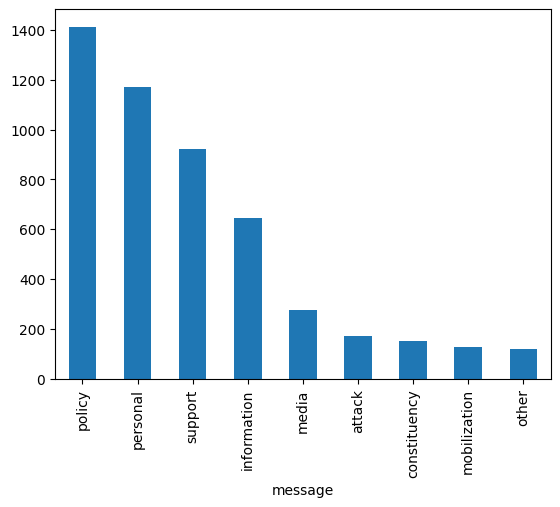

```python
kgposts.message.value_counts().plot.bar()
```

So now we know which type of message is the most popular, but what about the platform they're posted on? Let's use the same process to determine which platform appears to be the most popular.

```python
platform_type_count = kgposts.source.value_counts()
platform_type_count
```

| source | count |
| --- | --- |
| twitter | 2500 |
| facebook | 2500 |

**dtype:** int64

In this case, it looks like it is split perfectly in half! (the dataset contains 5,000 total posts). This was likely done purposefully during data collection. However, this raises a new question; although policy messages are the most popular overall, does this change across platforms? Let's find out!

```python
kgposts.groupby('source').message.value_counts()
```

| source | message | count |
| --- | --- | --- |
| facebook | policy | 744 |
|  | personal | 629 |
|  | support | 445 |
|  | information | 318 |
|  | media | 108 |
|  | other | 81 |
|  | attack | 63 |
|  | constituency | 57 |
|  | mobilization | 55 |
| twitter | policy | 667 |
|  | personal | 541 |
|  | support | 476 |
|  | information | 329 |
|  | media | 169 |
|  | attack | 109 |
|  | constituency | 95 |
|  | mobilization | 74 |
|  | other | 40 |

**dtype:** int64

It looks like the top five categories remain the same, but there are more than double the number of "other" posts on Facebook than on Twitter. Who knew!

Are legislators from certain states more likely to post attack messages than others?

```python
attack_by_state = kgposts.groupby('state')['message'].value_counts().loc[:, 'attack']
print(attack_by_state)
```

```
state
Alabama            1
Arizona            6
California        19
Colorado           2
Delaware           1
Florida            9
Georgia            5
Illinois           8
Indiana            7
Iowa               2
Kansas             5
Kentucky           7
Louisiana         14
Maryland           4
Massachusetts      1
Michigan           3
Missouri           3
Nevada             1
New Hampshire      1
New Jersey         3
New Mexico         1
New York           7
North Carolina     6
Ohio               5
Oklahoma           1
Pennsylvania       9
Rhode Island       1
South Carolina     3
South Dakota       1
Tennessee          4
Texas             23
Utah               2
Vermont            1
Virginia           1
Washington         1
West Virginia      2
Wisconsin          2
Name: count, dtype: int64
```

Whats the average number of attack messages per state?

```python
attack_by_state.mean()
```

```
4.648648648648648
```

Now lets compare against the top 5

```python
attack_by_state.nlargest(5)
```

| state | count |
| --- | --- |
| Texas | 23 |
| California | 19 |
| Louisiana | 14 |
| Florida | 9 |
| Pennsylvania | 9 |

**dtype:** int64

Texas, California and Louisiana send more than double the mean! They skew the distribution right. Lets see what the median is...

```python
attack_by_state.median()
```

```
3.0
```

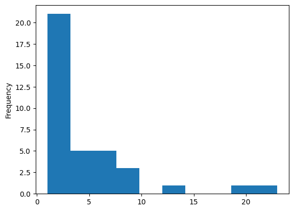

```python
attack_by_state.plot.hist()
```

```python
from google.colab import drive
drive.mount('/content/drive')
```

[output not shown]

```python
!cd ..
!cd /content/drive/MyDrive/
!ls
```

```
legislators-current.csv     political_social_media.csv	remaining_legislators.csv
legislators-historical.csv  README.md
```

```python
%%shell
jupyter nbconvert --to html /content/Teragram04.github.io/
```

[output not shown]

[output not shown]